# Project 2 Report

Ben Goldstone

3/10/2023

# Topic: Factors that effect food choice.

**Interest**: We thought that food was a great universal topic to ask people. Everybody needs to eat to survive, so this is a great topic in order to limit bias and also who doesn’t like food?

**Questions Asked**:

1. Which of the following factors most influence your food choices? (Please select all that apply)
2. How much does cost factor into your food choices?
3. How often do you eat out at restaurants or order takeout?
4. How often do you consider the nutritional value of the foods you eat?
5. When making food choices, how important is it to you to consider the environmental impact of the food you consume?

**Survey Sent**: Posted to Facebook (older relatives), Instagram (General Friends), Women’s Soccer Team, Direct Muhlenberg friend group, Muhlenberg Stem students

**Sample Size**: 50

## Hypothesis

People who order food because of price will likely eat out less than those who do not care about price.

## Data Collection

```r
library(readr)
DataCollectionSurvey <- read_csv("~/Projects/Project 2/DataCollectionSurvey.csv",
    col_types = cols(FoodChoiceInfluencers = col_character(),
        FrequencyOfRestaurantsOrTakeout = col_character(),
        NutritionalValueConsideration = col_character(),
        EnvironmentalImpactConsideration = col_character(),
        CostConsideration = col_integer()))
head(DataCollectionSurvey)
```

```
## # A tibble: 6 × 5
##   FoodChoiceInfluencers FrequencyOfRestaur… NutritionalValue… EnvironmentalImpa…
##   <chr>                 <chr>               <chr>             <chr>
## 1 Taste                 Once per week       Sometimes         Somewhat important
## 2 Price                 Once per week       Sometimes         Somewhat important
## 3 Convenience           Once per week       Sometimes         Somewhat important
## 4 Health                Once per week       Sometimes         Somewhat important
## 5 Taste                 A few times per mo… Always            Very important
## 6 Price                 A few times per mo… Always            Very important
## # … with 1 more variable: CostConsideration <int>
```

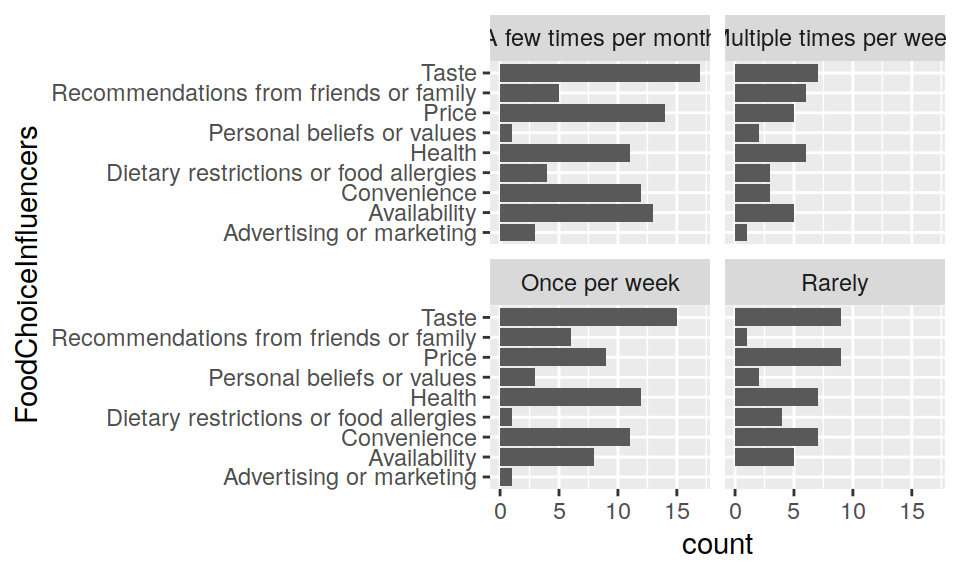

```r
gf_barh( ~ FoodChoiceInfluencers | FrequencyOfRestaurantsOrTakeout,data = na.omit(DataCollectionSurvey))
```

```r
tally(~ FoodChoiceInfluencers | FrequencyOfRestaurantsOrTakeout,data =na.omit( DataCollectionSurvey))
```

```
##                                         FrequencyOfRestaurantsOrTakeout
## FoodChoiceInfluencers                    A few times per month
##   Advertising or marketing                                   3
##   Availability                                              13
##   Convenience                                               12
##   Dietary restrictions or food allergies                     4
##   Health                                                    11
##   Personal beliefs or values                                 1
##   Price                                                     14
##   Recommendations from friends or family                     5
##   Taste                                                     17
##                                         FrequencyOfRestaurantsOrTakeout
## FoodChoiceInfluencers                    Multiple times per week Once per week
##   Advertising or marketing                                     1             1
##   Availability                                                 5             8
##   Convenience                                                  3            11
##   Dietary restrictions or food allergies                       3             1
##   Health                                                       6            12
##   Personal beliefs or values                                   2             3
##   Price                                                        5             9
##   Recommendations from friends or family                       6             6
##   Taste                                                        7            15
##                                         FrequencyOfRestaurantsOrTakeout
## FoodChoiceInfluencers                    Rarely
##   Advertising or marketing                    0
##   Availability                                5
##   Convenience                                 7
##   Dietary restrictions or food allergies      4
##   Health                                      7
##   Personal beliefs or values                  2
##   Price                                       9
##   Recommendations from friends or family      1
##   Taste                                       9
```

```r
nrow(DataCollectionSurvey)
```

```
## [1] 228
```

## Graph Analysis & Statistic

People who eat in restaurants or take out from restaurants more frequently typically have more consistent food influences.

Of all of the people who eat out and care about price, **37.84%** eat out a few time a month because of price.

## Reflection

I think this experiment went fairly well for the most part. If I were to try and do this experiment again, I would probably ask people to select their most influential trait in deciding to go out to a restaurant or take out food instead of asking them to check as many as they want.